# Cyclistic analysis

Daniel

3 02 2022

This markdown file has been created for the purpose of documenting the steps that are necessary to answer the business task: “In what ways do members and casual riders use Divvy bikes differently?”. This analysis will be performed based on the last 12 months of Cyclystic trip data (February 2021 - January 2022).

The first step is importing all the packages that will be useful for this analysis.

```r
library(tidyverse)  #helps wrangle data
library(lubridate)  #helps wrangle date attributes
```

```r
library(ggplot2)
```

Next, it is time to import the data.

```r
feb_2021 <- read.csv("202102-divvy-tripdata.csv")
mar_2021 <- read.csv("202103-divvy-tripdata.csv")
apr_2021 <- read.csv("202104-divvy-tripdata.csv")
may_2021 <- read.csv("202105-divvy-tripdata.csv")
jun_2021 <- read.csv("202106-divvy-tripdata.csv")
jul_2021 <- read.csv("202107-divvy-tripdata.csv")
aug_2021 <- read.csv("202108-divvy-tripdata.csv")
sep_2021 <- read.csv("202109-divvy-tripdata.csv")
oct_2021 <- read.csv("202110-divvy-tripdata.csv")
nov_2021 <- read.csv("202111-divvy-tripdata.csv")
dec_2021 <- read.csv("202112-divvy-tripdata.csv")
jan_2022 <- read.csv("202201-divvy-tripdata.csv")
```

To make analysis easier, these files will be combined into a single data frame. However, before this can happen, it is necessary to inspect them to ensure this can be done without issues.

```r
str(feb_2021)
```

```
## 'data.frame':    49622 obs. of  13 variables:
##  $ ride_id           : chr  "89E7AA6C29227EFF" "0FEFDE2603568365" "E6159D746B2DBB91" "B32D3199F1C2E75B" ...
##  $ rideable_type     : chr  "classic_bike" "classic_bike" "electric_bike" "classic_bike" ...
##  $ started_at        : chr  "2021-02-12 16:14:56" "2021-02-14 17:52:38" "2021-02-09 19:10:18" "2021-02-02 17:49:41" ...
##  $ ended_at          : chr  "2021-02-12 16:21:43" "2021-02-14 18:12:09" "2021-02-09 19:19:10" "2021-02-02 17:54:06" ...
##  $ start_station_name: chr  "Glenwood Ave & Touhy Ave" "Glenwood Ave & Touhy Ave" "Clark St & Lake St" "Wood St & Chicago Ave" ...
##  $ start_station_id  : chr  "525" "525" "KA1503000012" "637" ...
##  $ end_station_name  : chr  "Sheridan Rd & Columbia Ave" "Bosworth Ave & Howard St" "State St & Randolph St" "Honore St & Division St" ...
##  $ end_station_id    : chr  "660" "16806" "TA1305000029" "TA1305000034" ...
##  $ start_lat         : num  42 42 41.9 41.9 41.8 ...
##  $ start_lng         : num  -87.7 -87.7 -87.6 -87.7 -87.6 ...
##  $ end_lat           : num  42 42 41.9 41.9 41.8 ...
##  $ end_lng           : num  -87.7 -87.7 -87.6 -87.7 -87.6 ...
##  $ member_casual     : chr  "member" "casual" "member" "member" ...
```

```r
str(jan_2022)
```

```
## 'data.frame':    103770 obs. of  13 variables:
##  $ ride_id           : chr  "C2F7DD78E82EC875" "A6CF8980A652D272" "BD0F91DFF741C66D" "CBB80ED419105406" ...
##  $ rideable_type     : chr  "electric_bike" "electric_bike" "classic_bike" "classic_bike" ...
##  $ started_at        : chr  "2022-01-13 11:59:47" "2022-01-10 08:41:56" "2022-01-25 04:53:40" "2022-01-04 00:18:04" ...
##  $ ended_at          : chr  "2022-01-13 12:02:44" "2022-01-10 08:46:17" "2022-01-25 04:58:01" "2022-01-04 00:33:00" ...
##  $ start_station_name: chr  "Glenwood Ave & Touhy Ave" "Glenwood Ave & Touhy Ave" "Sheffield Ave & Fullerton Ave" "Clark St & Bryn Mawr Ave" ...
##  $ start_station_id  : chr  "525" "525" "TA1306000016" "KA1504000151" ...
##  $ end_station_name  : chr  "Clark St & Touhy Ave" "Clark St & Touhy Ave" "Greenview Ave & Fullerton Ave" "Paulina St & Montrose Ave" ...
##  $ end_station_id    : chr  "RP-007" "RP-007" "TA1307000001" "TA1309000021" ...
##  $ start_lat         : num  42 42 41.9 42 41.9 ...
##  $ start_lng         : num  -87.7 -87.7 -87.7 -87.7 -87.6 ...
##  $ end_lat           : num  42 42 41.9 42 41.9 ...
##  $ end_lng           : num  -87.7 -87.7 -87.7 -87.7 -87.6 ...
##  $ member_casual     : chr  "casual" "casual" "member" "casual" ...
```

After taking a look at the structure of every file (only the first and last were shown here for brevity’s sake), it is apparent that they share the same structures and column names. Therefore, it is time to combine them into a single data frame.

```r
all_trips <- bind_rows(feb_2021, mar_2021, apr_2021, may_2021, jun_2021, jul_2021, aug_2021, sep_2021, oct_2021, nov_2021, dec_2021, jan_2022)
```

Before undergoing analysis there are a few things that can be done to inspect and prepare the data. I will start by checking whether the two types of memberships in the member_casual column were consistent in naming.

```r
unique(all_trips[c("member_casual")]) ##Displays the unique values that appear in the "member_casual" column
```

```
##   member_casual
## 1        member
## 2        casual
```

Only two unique values appear in this column, meaning that naming was indeed consistent across all the files. The next step is to create additional columns for day, month and year as the current “started_at” and “ended_at” is too general for meaningful analysis.

```r
all_trips$date <- as.Date(all_trips$started_at)
all_trips$month <- format(as.Date(all_trips$date), "%m")
all_trips$day <- format(as.Date(all_trips$date), "%d")
all_trips$year <- format(as.Date(all_trips$date), "%Y")
all_trips$day_of_week <- format(as.Date(all_trips$date), "%A")
```

Adding a column representing the length of each ride is the next step in preparing the data.

```r
all_trips$started_at <- strptime(all_trips$started_at, format = "%Y-%m-%d %H:%M:%OS")
all_trips$ended_at <- strptime(all_trips$ended_at, format = "%Y-%m-%d %H:%M:%OS") ## For the difftime calculation to work properly both of the columns need to first be converted from characters to time objects.
all_trips$ride_length <- difftime(all_trips$ended_at, all_trips$started_at) ## Subtracts the start time from the end time.
all_trips$ride_length <- as.numeric(as.character(all_trips$ride_length)) ## Converts the format of the values in "ride_length" to numeric to enable calculations later on
```

The last step in preparing the data is removing certain unnecessary rows. Sometimes the bikes were taken out for a quality check, and in some cases the ride length is negative, rendering these rows redundant.

```r
all_trips_v2 <- all_trips[!(all_trips$start_station_name == "HQ QR" | all_trips$ride_length<0),]
```

To get a general idea about the data, I will first take a look at some statistics about the length of trips.

```r
summary(all_trips_v2$ride_length)
```

```
##    Min. 1st Qu.  Median    Mean 3rd Qu.    Max.    NA's
##       0     403     717    1316    1303 3356649     114
```

The next step is comparing statistics for ride length between casual users and members.

```r
aggregate(all_trips_v2$ride_length ~ all_trips_v2$member_casual, FUN = mean)
```

```
##   all_trips_v2$member_casual all_trips_v2$ride_length
## 1                     casual                1922.2882
## 2                     member                 816.5232
```

```r
aggregate(all_trips_v2$ride_length ~ all_trips_v2$member_casual, FUN = median)
```

```
##   all_trips_v2$member_casual all_trips_v2$ride_length
## 1                     casual                      957
## 2                     member                      574
```

```r
aggregate(all_trips_v2$ride_length ~ all_trips_v2$member_casual, FUN = max)
```

```
##   all_trips_v2$member_casual all_trips_v2$ride_length
## 1                     casual                  3356649
## 2                     member                    93596
```

```r
aggregate(all_trips_v2$ride_length ~ all_trips_v2$member_casual, FUN = min)
```

```
##   all_trips_v2$member_casual all_trips_v2$ride_length
## 1                     casual                        0
## 2                     member                        0
```

Clearly, casual users tend to take the bikes out for longer rides. Both the mean and median for casual users are significantly higher. This suggests that the users who decide to become members generally do shorter trips, perhaps more often. Checking the amount of trips taken out by the two types of users is also useful information.

```r
all_trips_v2 %>% count(member_casual)
```

```
##   member_casual       n
## 1        casual 2529276
## 2        member 3072464
## 3          <NA>     114
```

Members took out around 500 000 more trips during the year than casual users, confirming the fact that members tend to use the bikes more frequently for shorter trips. Next, let’s take a look at the differences in average ride times for each day of the week between members and casual users.

```r
all_trips_v2$day_of_week <- ordered(all_trips_v2$day_of_week, levels=c("Sunday", "Monday", "Tuesday", "Wednesday", "Thursday", "Friday", "Saturday")) ## First it is good to put the days of the week in the correct order.
aggregate(all_trips_v2$ride_length ~ all_trips_v2$member_casual + all_trips_v2$day_of_week, FUN = mean)
```

```
##    all_trips_v2$member_casual all_trips_v2$day_of_week all_trips_v2$ride_length
## 1                      casual                   Sunday                2254.6107
## 2                      member                   Sunday                 939.8343
## 3                      casual                   Monday                1915.5745
## 4                      member                   Monday                 791.4723
## 5                      casual                  Tuesday                1676.1845
## 6                      member                  Tuesday                 767.1502
## 7                      casual                Wednesday                1664.7325
## 8                      member                Wednesday                 766.3520
## 9                      casual                 Thursday                1669.3141
## 10                     member                 Thursday                 765.2519
## 11                     casual                   Friday                1822.0102
## 12                     member                   Friday                 799.0695
## 13                     casual                 Saturday                2084.7970
## 14                     member                 Saturday                 914.4533
```

The relationship of casual members taking longer trips remains consistent over every day of the week. Moreover, both casual users and members do longer trips on the weekends. Now, to get some more specific statistics.

```r
all_trips_v2 %>%
     mutate(weekday = wday(started_at, label = TRUE)) %>%
     group_by(member_casual, weekday) %>%
     summarise(number_of_rides = n()
               ,average_duration = mean(ride_length)) %>%
     arrange(member_casual, weekday)
```

```
## # A tibble: 15 x 4
## # Groups:   member_casual [3]
##    member_casual weekday number_of_rides average_duration
##    <chr>         <ord>             <int>            <dbl>
##  1 casual        Sun              480684            2255.
##  2 casual        Mon              286714            1916.
##  3 casual        Tue              274900            1676.
##  4 casual        Wed              279243            1665.
##  5 casual        Thu              286259            1669.
##  6 casual        Fri              363696            1822.
##  7 casual        Sat              557780            2085.
##  8 member        Sun              376198             940.
##  9 member        Mon              418443             791.
## 10 member        Tue              468695             767.
## 11 member        Wed              478734             766.
## 12 member        Thu              453563             765.
## 13 member        Fri              445130             799.
## 14 member        Sat              431701             914.
## 15 <NA>          <NA>                114              NA
```

Interestingly enough, while it is true that members take out trips more frequently, the data frame above shows that during weekends, casual users took out significantly more trips than members (104486 more trips on Sundays and 126079 more trips on Saturdays). This suggests that casual users are particularly likely to take out bikes during their free time to take leisure trips, while members use them more regularly for shorter trips, perhaps as a primary means of communication. Now to get a visual understanding of this data, let’s create some charts.

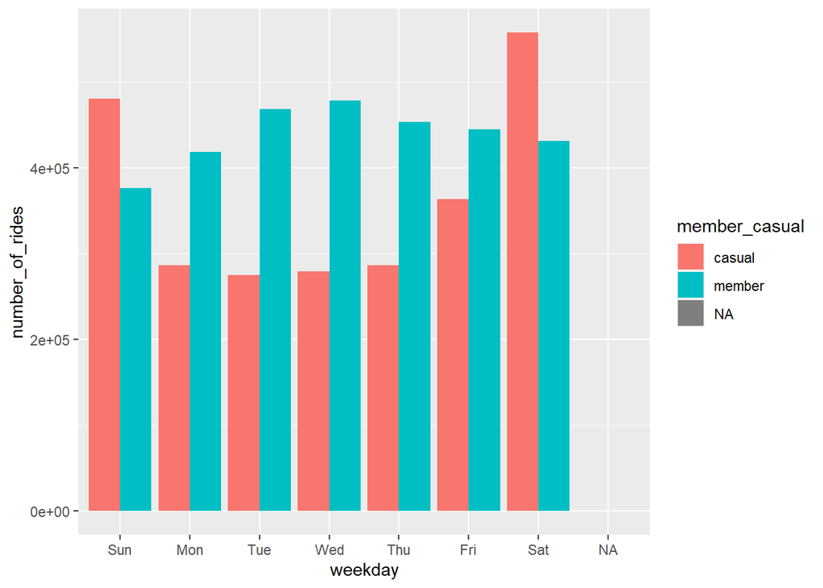

```r
all_trips_v2 %>%
  mutate(weekday = wday(started_at, label = TRUE)) %>%
  group_by(member_casual, weekday) %>%
  summarise(number_of_rides = n()
            ,average_duration = mean(ride_length)) %>%
  arrange(member_casual, weekday)  %>%
  ggplot(aes(x = weekday, y = number_of_rides, fill = member_casual)) +
  geom_col(position = "dodge")
```

The above chart displays the statistics discussed above, and shows clearly that members generally take out significantly more rides except on the weekends. Let’s take a look at another visualisation.

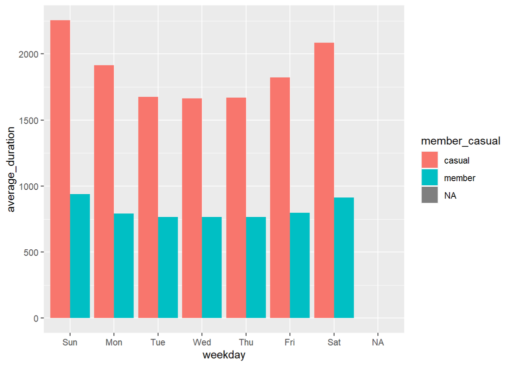

```r
all_trips_v2 %>%
  mutate(weekday = wday(started_at, label = TRUE)) %>%
  group_by(member_casual, weekday) %>%
  summarise(number_of_rides = n()
            ,average_duration = mean(ride_length)) %>%
  arrange(member_casual, weekday)  %>%
  ggplot(aes(x = weekday, y = average_duration, fill = member_casual)) +
  geom_col(position = "dodge")
```

This bar chart clearly shows the disproportion between the length of rides taken out by the two user types. Based on the findings from this data, the main differences between the two types of users are: - Frequency of trips (members take out bikes more often) - Length of trips (casual users do longer trips) - Circumstance of trips (casual users do more trips on weekends) Perhaps casual users could be convinced to become members if they were incentivized to take bikes out more often, for shorter distances.